# Week 2 Exploratory Analysis of SwiftKey data

Emmanuel Okyere Darko

4/15/2021

## Executive Summary

As new phones or electronics emerges, the need for completing task quickly is also rising. `Swiftkey` is a leading keyboard text prediction that predicts the next word or next phrase when one starts typing. The goal of this project is to predict a possible next word as users start typing in order to suggest or improve typing speed using `SwiftKey` data. This report mainly focuses of the Exploratory Analysis of the data to develop insight about the data. link for full code can be accessed here: [My github](https://github.com/gmokyere/Statistics_Machine_Learning_R/tree/main/Data%20Science%20Capstone  
)

1. In summary,
- The number of `words` in each subject file will be found
- The number of `lines` in each subject file will be found
- The longest line of words in each subject file will be found
- Most Frequent words used

## Libraries

```r
# NLP tools
library("R.utils")
library(NLP)
library(tm)

## Visualization
library(cowplot) #multi panel plot
library(ggplot2)
library("wordcloud") # word-cloud generator
library(plotly) #interactive plot

## Text cleaning
library(stringr); library("tidytext")

## For messy data cleaning
library(dplyr); library(tidyverse)


set.seed(2222)
```

## Getting data

This dataset was downloaded from , a leading keyboard text prediction, through `Coursera` Data Science Capstone by John Hopkins University here [Data](https://d396qusza40orc.cloudfront.net/dsscapstone/dataset/Coursera-SwiftKey.zip)

```r
data_folder <- "Data"
zip_url <- "https://d396qusza40orc.cloudfront.net/dsscapstone/dataset/Coursera-SwiftKey.zip"
zip_name <- "Coursera-SwiftKey.zip"
download_path <- paste(getwd(), zip_name, sep = "/")

if (!file.exists(download_path)){
  download.file(url, destfile=download_path, method="curl")
}
unzip(zipfile=download_path, exdir=data_folder) ##extracted folder is "final"
```

## Exploratory Analysis

Read all text files in a particular language directory, find the number of lines in each, the longest line of words and number of words in each subject line.

```r
flist <- list.files("Data/final", pattern = ".*en_.*.txt", recursive = T)

get_info <-lapply(paste("Data/final", flist, sep = "/"), function(filename){
      ## Check file size
      fsize = file.size(filename)[1]/1024/1024

      ## Read subset of data
      con <- file(filename, "r") #open connection
      all_lines = readLines(con)
      #readLines(con, 5) ## read first 5 lines

      ## check number of lines in the file
      #NROW(readLines(con_en_us_twitter))
      nlines <- sapply(filename, countLines)

      ##longest line
      nchars = lapply(all_lines, nchar)
      longest_line <- which.max(nchars) ## determine index of max

      ## split based on one or more white spaces and find length
      nwords <- sum(sapply(strsplit(all_lines, "\\s+"), length))

      close(con)
      return(c(filename, round(as.numeric(fsize),2), nlines, longest_line, nwords))
})
```

#### Neatly convert list to dataframe and visualize

```r
us_df <- data.frame(matrix(unlist(get_info), nrow=length(get_info), byrow=T))
colnames(us_df) <- c("file", "fsize", "num_of_lines", "longest_line", "nwords")
us_df
```

```
##                                 file  fsize num_of_lines longest_line   nwords
## 1   Data/final/en_US/en_US.blogs.txt 200.42       899288       483415 37334149
## 2    Data/final/en_US/en_US.news.txt 196.28      1010242       123628 34372814
## 3 Data/final/en_US/en_US.twitter.txt 159.36      2360148           26 30373565
```

### Summary Statistics

#### Word counts, line counts and longest line in each US file

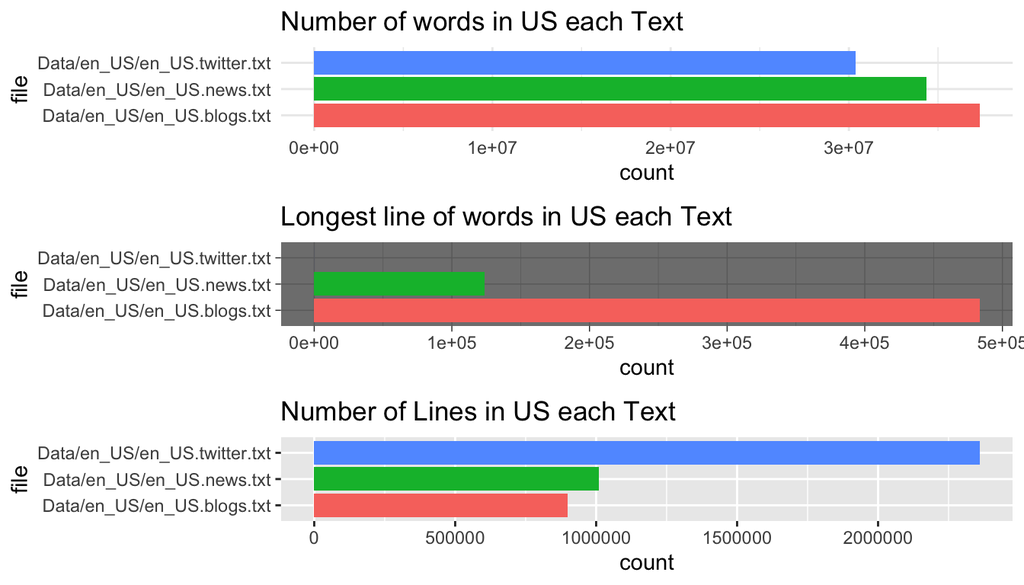

#### Word Frequencies

2. Given the huge amount of dataset we hav, we will only sample `10%` of the data to explore

```r
count_words_l <- lapply(paste("Data/final", flist, sep = "/"), function(path){
      ## REad file
      #path = "Data/en_US/en_US.blogs.txt"
      con <- file(path, "r") # open connection
      all_lines = readLines(con)

      close(con) #connection

      ## number of lines
      nlines = sapply(path, countLines)

      ## Sample 10% of words
      sub_lines <- all_lines[sample(1:nlines, nlines*0.1, replace = FALSE)]

      #remove paragraphs
      sub_lines <- sub_lines %>% stringr::str_replace_all(pattern = "\n", replacement = "")

      text_df <- tibble(Text = sub_lines) ## put nealty into a df
      text_words <- text_df %>% unnest_tokens(output = word, input = Text) # make each row per word

      ## Remove stop words
      data("stop_words")
      text_words <- text_words %>% anti_join(stop_words)

      ##check for most frequent words
      count_words <- text_words %>% count(word, sort = TRUE)
      return(count_words)
})
```

### Word cloud

1. From left to right, Blogs, News, Twitter. As seen from below, US Blogs mostly frequent words are`time, love and people`; News words are more about `schools, county and city`, while most words used on Twitter are `follow, people, night, weekend`

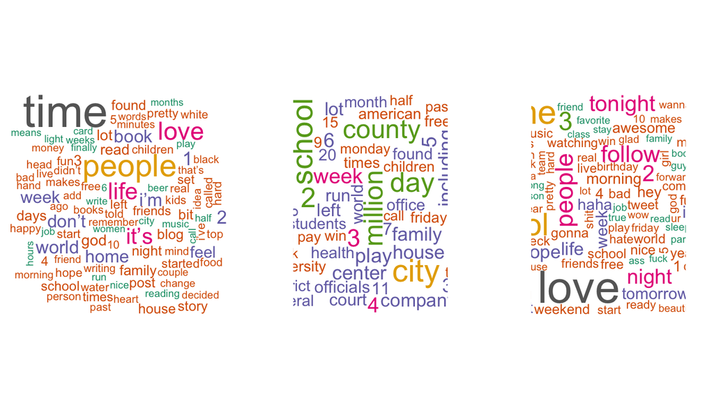

# Frequent words

```r
topn <- 20
### GGplot summary
top_n_words_blogs <- count_words_l[[1]] %>% filter(n>count_words_l[[1]]$n[topn]) %>%
                  mutate(word = reorder(word, n))

top_n_words_news <- count_words_l[[2]] %>%
                  filter(n>count_words_l[[2]]$n[topn]) %>% mutate(word = reorder(word, n))

top_n_words_tweet <- count_words_l[[3]] %>%
                  filter(n>count_words_l[[1]]$n[topn]) %>% mutate(word = reorder(word, n))
```

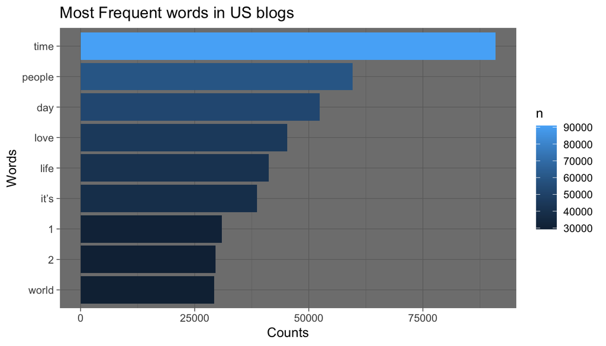

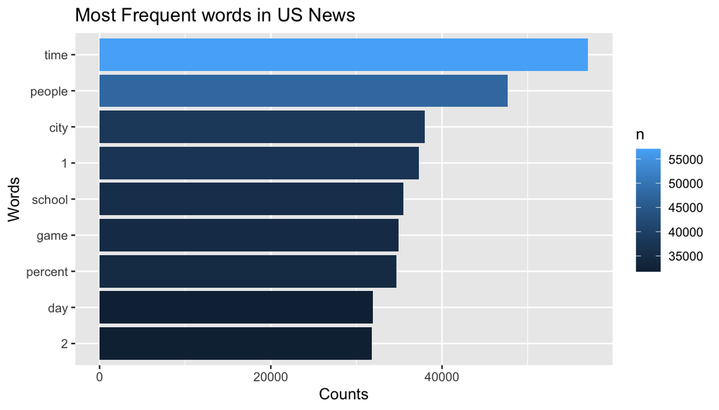

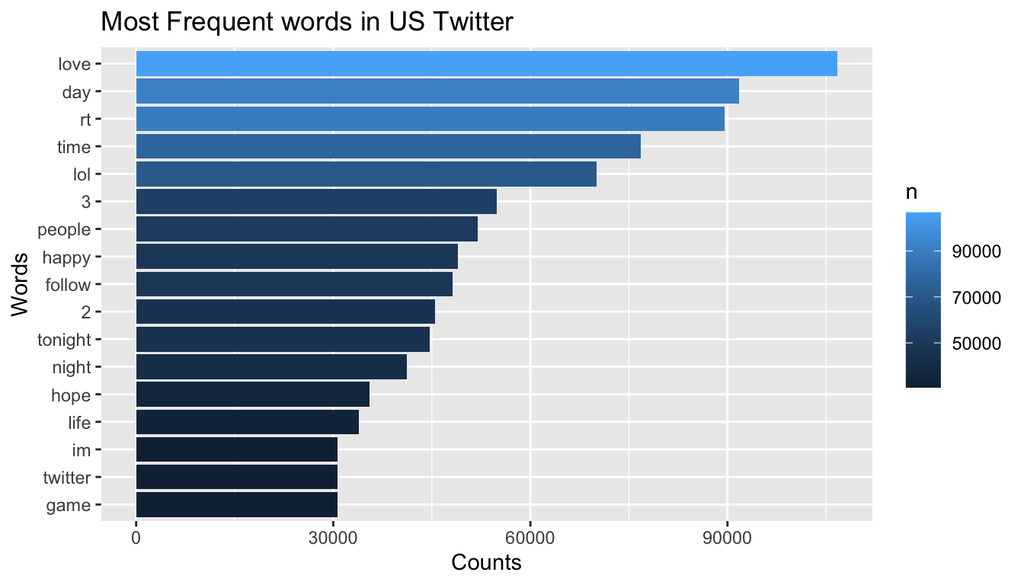

## Modelling

```r
### N-Grams

## REad file
#path = "Data/en_US/en_US.blogs.txt"
con <- file(paste("Data/final", flist[1], sep = "/"), "r") # open connection
all_lines = readLines(con)

close(con) #connection

## number of lines
nlines = sapply(paste("Data/final", flist[1], sep = "/"), countLines)

## Sample 10% of words
sub_lines <- all_lines[sample(1:nlines, nlines*0.1, replace = FALSE)]

sub_lines <- sub_lines %>% stringr::str_replace_all(pattern = "\n", replacement = "")

text_df <- tibble(Text = sub_lines) ## put neatly into a df
```

```r
n_gram <- text_df %>% unnest_tokens(output = word, input = Text, token = "ngrams", n= 3)
n_gram
```

```
## # A tibble: 3,589,732 x 1
##    word
##    <chr>
##  1 the sound of
##  2 sound of frogs
##  3 of frogs calling
##  4 frogs calling down
##  5 calling down rain
##  6 <NA>
##  7 today it's our
##  8 it's our first
##  9 our first challenge
## 10 first challenge for
## # … with 3,589,722 more rows
```